# R Notebook: natural language processing (text as multivariate data)

```r
library(devtools);
library(humanVerseWSU);

path.github = "https://raw.githubusercontent.com/MonteShaffer/humanVerseWSU/master/";

include.me = paste0(path.github, "misc/functions-nlp.R");
# source_url( include.me );
include.me = paste0(path.github, "humanVerseWSU/R/functions-encryption.R");
source_url( include.me );
```

```
## SHA-1 hash of file is bb54547500147dcb77047053bbf5c4bd153ffc38
```

```r
path.to.nascent = "C:/Users/Alexander Nevsky/Dropbox/WSU-419/Fall 2020/__student_access__/unit_02_confirmatory_data_analysis/nascent/";

folder.nlp = "nlp/";
path.to.nlp = paste0(path.to.nascent, folder.nlp);
```

# 1 (NLP) Natural Language Processing

There was quite a bit of interest on this topic. How can we perform multivariate analysis on text. Most think of data as numbers, but text is certainly data and certainly multivariate.

Below is an email I recently sent to a student not in our program which stands as a good summary of the topic.

```
Hi M****,

I am in the process of building a few "NLP" notebooks for my class.  I can share those with you in a few weeks.

I have used python in the past for a large project, but it seems like R has more than caught up.

I am leaning towards the package quanteda, but there are several libraries out there:

https://quanteda.io/articles/pkgdown/comparison.html

I like this library because it looks like it is "most hackable" - I have developed a custom NLP-LSA approach and believe I can plug it into this library.

This link compares two books "Sense and Sensibility" and "Moby Dick" ....   A good walk through on some basics of NLP.

https://quanteda.io/articles/pkgdown/replication/digital-humanities.html

I think those two links should help you get started.
```

## 1.1 Choosing “quanteda”

I have reviewed and tested 3 packages available in R. I will want to do my own thing often, and so the package needs to be “hackable”. For example, I may want to add my own collection of stop words. Or I may want to write my own “n-gram” text processing algorithm. Such elements are things I performed on a “concept-search engine” using patent data to answer the question: “is your idea patentable?” This topic will be an (optional) mastery notebook coming soon.

```r
## Remember that RStudio links to some files and makes "installation" a bit more difficult than it needs to be.  I would recommend closing RStudio and installing the packages in RGui, then come back to RStudio to use them.


library(devtools);

library(quanteda);  # install.packages("quanteda", dependencies=TRUE);
library(quanteda.corpora); # devtools::install_github("quanteda/quanteda.corpora");
library(quanteda.textmodels); # install.packages("quanteda.textmodels", dependencies=TRUE);
library(LIWCalike); # devtools::install_github("kbenoit/LIWCalike");
```

Choosing “quanteda” is one of several good choices. We will see how it does. You will likely see me write a lot of custom functions to show you the “inner mechanics” of some aspects of NLP.

## 1.2 The Brothers Grimm

We will use short stories to introduce the topic: https://www.gutenberg.org/ebooks/2591. I believe there are 60+ short stories.

- Plain text: https://www.gutenberg.org/files/2591/2591-0.txt
- HTML: https://www.gutenberg.org/files/2591/2591-h/2591-h.htm
- Special HTML: https://www.gutenberg.org/files/52521/52521-h/52521-h.htm

HTML has anchors to make processing easier.

### 1.2.1 Getting the Data

Good data provenance requires a library and storage container. So we will manually download a copy and reference that copy.

```r
gutenberg.id = 2591;

path.to.gutenberg = paste0(path.to.nlp,"_data_/gutenberg/");
  createDirRecursive(path.to.gutenberg);
path.to.grimm = paste0(path.to.gutenberg,gutenberg.id,"/");
  createDirRecursive(path.to.grimm);


local.data.path = path.to.gutenberg; # currently required by grabHTML ... TODO: fix


txt.file.remote = "https://www.gutenberg.org/files/2591/2591-0.txt";
txt.file.local = paste0(path.to.grimm,"fairytales.txt");

  my.txt = grabHTML(txt.file.local, txt.file.remote);
```

```
## [1] "grabHTML() ... from cache ... C:/Users/Alexander Nevsky/Dropbox/WSU-419/Fall 2020/__student_access__/unit_02_confirmatory_data_analysis/nascent/nlp/_data_/gutenberg/2591/fairytales.txt"
```

```r
# library(readtext);
# data.grimm.txt = texts(readtext( file.local ));




html.file.remote = "https://www.gutenberg.org/files/2591/2591-h/2591-h.htm";
html.file.local = paste0(path.to.grimm,"fairytales.html");

  my.html = grabHTML(html.file.local, html.file.remote);
```

```
## [1] "grabHTML() ... from cache ... C:/Users/Alexander Nevsky/Dropbox/WSU-419/Fall 2020/__student_access__/unit_02_confirmatory_data_analysis/nascent/nlp/_data_/gutenberg/2591/fairytales.html"
```

### 1.2.2 Getting Short Stories and Paragraphs From Data

The “HTML” form is easier to parse. A “view-source” on the raw HTML shows that `<h2>` is an important key. It appears each paragraph is in a `<p>` tag, and there are some characters that need to be converted from html-entities: `&lsquo;` and poems appear to be in `<pre>` tags.

#### 1.2.2.1 HTML entitites

```r
str = '<pre xml:space="preserve">
 &lsquo;No care and no sorrow,
  A fig for the morrow!
  We&rsquo;ll laugh and be merry,
  Sing neigh down derry!&rsquo;
</pre>';

cleanupHTMLentities = function(str, find="fs", replace="rs")
  {
  fs = c("&lsquo;", "&rsquo;", "&mdash;");  # mdash is not a hyphen.
  rs = c("'"      , "'"      , " -- ");       # ASCII replaces
  cs = c("^[^"    , "^]^"    , " ^-^ ");      # custom replaces
  nfs = length(fs);
  for(i in 1:nfs)
    {
    myf = eval(parse(text = find));
    myr = eval(parse(text = replace));

    str = gsub(myf[i],myr[i], str, fixed=TRUE);
    }
  str;
  }

str;
```

```
## [1] "<pre xml:space=\"preserve\">\n &lsquo;No care and no sorrow,\n  A fig for the morrow!\n  We&rsquo;ll laugh and be merry,\n  Sing neigh down derry!&rsquo;\n</pre>"
```

```r
cleanupHTMLentities(str);
```

```
## [1] "<pre xml:space=\"preserve\">\n 'No care and no sorrow,\n  A fig for the morrow!\n  We'll laugh and be merry,\n  Sing neigh down derry!'\n</pre>"
```

#### 1.2.2.2 Parse into dataframe and cache

```r
cache.file.local = gsub(".html", ".rds", html.file.local, fixed=TRUE);

timer.start = as.numeric(Sys.time());


if(!file.exists(cache.file.local))
{
  df.grimm = NULL;
chap.n = 0;
para.n = 1;
title = "THE BROTHERS GRIMM FAIRY TALES";
what  = "-INTRO-";

### let's trim around gutenberg stuff
start = "*** START OF THIS PROJECT GUTENBERG EBOOK GRIMMS' FAIRY TALES ***";
end = "End of Project Gutenberg";

tmp = strsplit(my.html, end, fixed=TRUE)[[1]];     # str(tmp);
tmp1 = strsplit(tmp[1],  start, fixed=TRUE)[[1]];  # str(tmp1);

n.html = tmp1[2];

# there is one note ...  <div class="mynote">
start = '<div class="mynote">';
end = '</div>';

tmp = strsplit(n.html, start, fixed=TRUE)[[1]];     # str(tmp);
f.html = tmp[2];
tmp1 = strsplit(tmp[3],  end, fixed=TRUE)[[1]];     # str(tmp1);


strip_tags <- function(htmlString) {
  return(gsub("<.*?>", "", htmlString))
}


note = cleanupHTMLentities(tmp1[1],replace="cs");
note = strip_tags(note);
# note = removeWhiteSpace(note);
note = trimMe(note);
type = "note";

row = c(chap.n, what, title, para.n, type, note);
df.grimm = rbind(df.grimm, row);
  chap.n = 1+chap.n;
  para.n = 1;


### h2
tmp = strsplit(f.html,"<h2>", fixed=TRUE)[[1]];
idx.stories = 2:63

for(i in idx.stories)
  {
  story = tmp[i];
  what = paste0("STORY-",chap.n);
    story = cleanupHTMLentities(story,replace="cs");
    #story = removeWhiteSpace(story);
    story = trimMe(story);
  # story title
  stmp = strsplit(story, "</h2>", fixed=TRUE)[[1]];
  story.title = trimMe(stmp[1]);

  story = trimMe(stmp[2]);
  # let's keep paragraphs for a minute ...  <p> and <pre>
  # because of location of <pre>, I will explode on ending </p>
  # we will count <pre> as a paragraph with a poem flag ... # NOT PERFECT: it doesn't allow for multiple poems within a paragraph, see JORINDA.
  ptmp = strsplit(story, "</p>", fixed=TRUE)[[1]];

  # paragraphs = list();
  n.p = length(ptmp);
  k = 1;
  for(j in 1:n.p)  # i = 3; j = 12
    {
    para = ptmp[j];
    qtmp = strsplit(para, "<p>", fixed=TRUE)[[1]];
      poem = trimMe(strip_tags(qtmp[1]));
      if(is.na(poem)) { poem = ""; }
      if(poem != "")
        {
        # pinfo = list("type" = "poem", "text" = poem);
        # paragraphs[[k]] = pinfo;
        row = c(chap.n, what, story.title, k, "poem", poem);
        df.grimm = rbind(df.grimm, row);
        k = 1 + k;
        }
      prose = trimMe(strip_tags(qtmp[2]));
      if(is.na(prose)) { prose = ""; }
      if(prose != "")
        {
        prose = removeWhiteSpace(prose); # poems will keep line breaks
        # pinfo = list("type" = "prose", "text" = prose);
        # paragraphs[[k]] = pinfo;
        row = c(chap.n, what, story.title, k, "prose", prose);
        df.grimm = rbind(df.grimm, row);
        k = 1 + k;
        }
    ###
    }
  ### end of single story ...
  chap.n = 1+chap.n;
  }


df = as.data.frame(df.grimm);
  colnames(df) = c("chap.n", "chap.type", "title", "para.n", "para.type", "para.text");
  rownames(df) = paste0(df$chap.n,"-",df$para.n);
df$chap.n = as.numeric(df$chap.n);
df$para.n = as.numeric(df$para.n);

df.grimm = df;
saveRDS(df.grimm, cache.file.local);
    } else { df.grimm = readRDS(cache.file.local); }

timer.end = as.numeric(Sys.time());
timer.elapse = timer.end-timer.start;
print(paste0("Time elapsed: ", round(timer.elapse,2) ));
```

```
## [1] "Time elapsed: 0.01"
```

```r
df.grimm;
```

|  | chap.n | chap.type | title | para.n | para.type | para.text |
| --- | --- | --- | --- | --- | --- | --- |
| 0-1 | 0 | -INTRO- | THE BROTHERS GRIMM FAIRY TALES | 1 | note | The Brothers Grimm, Jacob (1785-1863) and Wilhelm (1786-1859), were born\r\r\n in Hanau, near Frankfurt, in the German state of Hesse. Throughout their\r\r\n lives they remained close friends, and bot… |
| 1-1 | 1 | STORY-1 | THE GOLDEN BIRD | 1 | prose | A certain king had a beautiful garden, and in the garden stood a tree which bore golden apples. These apples were always counted, and about the time when they began to grow ripe it was found that ever… |
| 1-2 | 1 | STORY-1 | THE GOLDEN BIRD | 2 | prose | Then the gardener^]^s eldest son set out and thought to find the golden bird very easily; and when he had gone but a little way, he came to a wood, and by the side of the wood he saw a fox sitting; so… |
| 1-3 | 1 | STORY-1 | THE GOLDEN BIRD | 3 | prose | Time passed on; and as the eldest son did not come back, and no tidings were heard of him, the second son set out, and the same thing happened to him. He met the fox, who gave him the good advice: but… |
| 1-4 | 1 | STORY-1 | THE GOLDEN BIRD | 4 | prose | Time passed on again, and the youngest son too wished to set out into the wide world to seek for the golden bird; but his father would not listen to it for a long while, for he was very fond of his so… |
| 1-5 | 1 | STORY-1 | THE GOLDEN BIRD | 5 | prose | When they came to the village, the son followed the fox^]^s counsel, and without looking about him went to the shabby inn and rested there all night at his ease. In the morning came the fox again and … |
| 1-6 | 1 | STORY-1 | THE GOLDEN BIRD | 6 | prose | Before the castle gate all was as the fox had said: so the son went in and found the chamber where the golden bird hung in a wooden cage, and below stood the golden cage, and the three golden apples t… |
| 1-7 | 1 | STORY-1 | THE GOLDEN BIRD | 7 | prose | So he set out once more on his journey, sighing, and in great despair, when on a sudden his friend the fox met him, and said, ^[^You see now what has happened on account of your not listening to my co… |
| 1-8 | 1 | STORY-1 | THE GOLDEN BIRD | 8 | prose | All went right, and the groom lay snoring with his hand upon the golden saddle. But when the son looked at the horse, he thought it a great pity to put the leathern saddle upon it. ^[^I will give him … |
| 1-9 | 1 | STORY-1 | THE GOLDEN BIRD | 9 | prose | Then he went his way very sorrowful; but the old fox came and said, ^[^Why did not you listen to me? If you had, you would have carried away both the bird and the horse; yet will I once more give you … |

[output cut: 898 more lines]

#### 1.2.2.3 Data exploration

I “assume” that the GRIMM stories paint the wolf in a negative light. So let’s start and just see how often the wolf appears versus a more pleasant word such as “garden”.

```r
search.garden = wildcardSearch("*garden*", "para.text", df=df.grimm);

search.garden;  # 43 paragraphs
```

|  | chap.n | chap.type | title | para.n | para.type | para.text |
| --- | --- | --- | --- | --- | --- | --- |
| 1-1 | 1 | STORY-1 | THE GOLDEN BIRD | 1 | prose | A certain king had a beautiful garden, and in the garden stood a tree which bore golden apples. These apples were always counted, and about the time when they began to grow ripe it was found that ever… |
| 1-2 | 1 | STORY-1 | THE GOLDEN BIRD | 2 | prose | Then the gardener^]^s eldest son set out and thought to find the golden bird very easily; and when he had gone but a little way, he came to a wood, and by the side of the wood he saw a fox sitting; so… |
| 7-1 | 7 | STORY-7 | BRIAR ROSE | 1 | prose | A king and queen once upon a time reigned in a country a great way off, where there were in those days fairies. Now this king and queen had plenty of money, and plenty of fine clothes to wear, and ple… |
| 10-5 | 10 | STORY-10 | THE FISHERMAN AND HIS WIFE | 5 | prose | Then the fish came swimming to him, and said, ^[^Well, what is her will? What does your wife want?^]^ ^[^Ah!^]^ said the fisherman, ^[^she says that when I had caught you, I ought to have asked you fo… |
| 10-6 | 10 | STORY-10 | THE FISHERMAN AND HIS WIFE | 6 | prose | Everything went right for a week or two, and then Dame Ilsabill said, ^[^Husband, there is not near room enough for us in this cottage; the courtyard and the garden are a great deal too small; I shoul… |
| 10-9 | 10 | STORY-10 | THE FISHERMAN AND HIS WIFE | 9 | prose | ^[^Well, what does she want now?^]^ said the fish. ^[^Ah!^]^ said the man, dolefully, ^[^my wife wants to live in a stone castle.^]^ ^[^Go home, then,^]^ said the fish; ^[^she is standing at the gate … |
| 15-17 | 15 | STORY-15 | THE ADVENTURES OF CHANTICLEER AND PARTLET | 17 | prose | Another day Chanticleer and Partlet agreed to go again to the mountains to eat nuts; and it was settled that all the nuts which they found should be shared equally between them. Now Partlet found a ve… |
| 16-1 | 16 | STORY-16 | RAPUNZEL | 1 | prose | There were once a man and a woman who had long in vain wished for a child. At length the woman hoped that God was about to grant her desire. These people had a little window at the back of their house… |
| 29-5 | 29 | STORY-29 | FREDERICK AND CATHERINE | 5 | prose | The husband thought to himself, ^[^If my wife manages matters thus, I must look sharp myself.^]^ Now he had a good deal of gold in the house: so he said to Catherine, ^[^What pretty yellow buttons the… |
| 32-1 | 32 | STORY-32 | THE PINK | 1 | prose | There was once upon a time a queen to whom God had given no children. Every morning she went into the garden and prayed to God in heaven to bestow on her a son or a daughter. Then an angel from heaven… |

[output cut: 33 more lines]

```r
search.wolf = wildcardSearch("*wolf*", "para.text", df=df.grimm);

search.wolf;   # 33 paragraphs
```

|  | chap.n | chap.type | title | para.n | para.type | para.text |
| --- | --- | --- | --- | --- | --- | --- |
| 5-2 | 5 | STORY-5 | OLD SULTAN | 2 | prose | Poor Sultan, who was lying close by them, heard all that the shepherd and his wife said to one another, and was very much frightened to think tomorrow would be his last day; so in the evening he went … |
| 5-3 | 5 | STORY-5 | OLD SULTAN | 3 | prose | Soon afterwards the wolf came and wished him joy, and said, ^[^Now, my good fellow, you must tell no tales, but turn your head the other way when I want to taste one of the old shepherd^]^s fine fat s… |
| 5-4 | 5 | STORY-5 | OLD SULTAN | 4 | prose | Then the wolf was very angry, and called Sultan ^[^an old rogue,^]^ and swore he would have his revenge. So the next morning the wolf sent the boar to challenge Sultan to come into the wood to fight t… |
| 5-5 | 5 | STORY-5 | OLD SULTAN | 5 | prose | The wolf and the wild boar were first on the ground; and when they espied their enemies coming, and saw the cat^]^s long tail standing straight in the air, they thought she was carrying a sword for Su… |
| 11-1 | 11 | STORY-11 | THE WILLOW-WREN AND THE BEAR | 1 | prose | Once in summer-time the bear and the wolf were walking in the forest, and the bear heard a bird singing so beautifully that he said: ^[^Brother wolf, what bird is it that sings so well?^]^ ^[^That is … |
| 11-2 | 11 | STORY-11 | THE WILLOW-WREN AND THE BEAR | 2 | prose | The bear and the wolf grew uneasy, and turned back and went into their holes. The young willow-wrens, however, continued to cry and scream, and when their parents again brought food they said: ^[^We w… |
| 15-18 | 15 | STORY-15 | THE ADVENTURES OF CHANTICLEER AND PARTLET | 18 | prose | Then Chanticleer was very sorry, and cried bitterly; and all the beasts came and wept with him over poor Partlet. And six mice built a little hearse to carry her to her grave; and when it was ready th… |
| 22-4 | 22 | STORY-22 | LITTLE RED-CAP [LITTLE RED RIDING HOOD] | 4 | prose | The grandmother lived out in the wood, half a league from the village, and just as Little Red-Cap entered the wood, a wolf met her. Red-Cap did not know what a wicked creature he was, and was not at a… |
| 22-6 | 22 | STORY-22 | LITTLE RED-CAP [LITTLE RED RIDING HOOD] | 6 | prose | ^[^Thank you kindly, wolf.^]^ |
| 22-13 | 22 | STORY-22 | LITTLE RED-CAP [LITTLE RED RIDING HOOD] | 13 | prose | The wolf thought to himself: ^[^What a tender young creature! what a nice plump mouthful^-^she will be better to eat than the old woman. I must act craftily, so as to catch both.^]^ So he walked for a… |

[output cut: 23 more lines]

This initial “search lookup” informs us that “wolf” appears in 33 distinct paragraphs and “garden” appears in 43 distinct paragraphs. A manual search of the HTML reveals “wolf” appears a total of 72 times in those 33 distinct paragraphs whereas “garden” appears a total of 66 times in those 43 distinct paragraphs.

**Note:** I may want to do some analysis on the “conversation” of characters in a story, so I replaced the single-quote HTML entities with a custom character.

### 1.2.3 Collapse a single story to its text

```r
# THE KING OF THE GOLDEN MOUNTAIN
# df.story = subsetDataFrame(df.grimm, "title", "==", "THE KING OF THE GOLDEN MOUNTAIN");
# outfile = paste0(path.to.grimm, "KING.GOLDEN.MOUNTAIN.txt");


# HANSEL AND GRETEL
df.story = subsetDataFrame(df.grimm, "title", "==", "HANSEL AND GRETEL");
outfile = paste0(path.to.grimm, "HANSEL.GRETEL.txt");



df.story;
```

|  | chap.n | chap.type | title | para.n | para.type | para.text |
| --- | --- | --- | --- | --- | --- | --- |
| 19-1 | 19 | STORY-19 | HANSEL AND GRETEL | 1 | prose | Hard by a great forest dwelt a poor wood-cutter with his wife and his two children. The boy was called Hansel and the girl Gretel. He had little to bite and to break, and once when great dearth fell o… |
| 19-2 | 19 | STORY-19 | HANSEL AND GRETEL | 2 | prose | The two children had also not been able to sleep for hunger, and had heard what their stepmother had said to their father. Gretel wept bitter tears, and said to Hansel: ^[^Now all is over with us.^]^ … |
| 19-3 | 19 | STORY-19 | HANSEL AND GRETEL | 3 | prose | When they had reached the middle of the forest, the father said: ^[^Now, children, pile up some wood, and I will light a fire that you may not be cold.^]^ Hansel and Gretel gathered brushwood together… |
| 19-4 | 19 | STORY-19 | HANSEL AND GRETEL | 4 | prose | Hansel and Gretel sat by the fire, and when noon came, each ate a little piece of bread, and as they heard the strokes of the wood-axe they believed that their father was near. It was not the axe, how… |
| 19-5 | 19 | STORY-19 | HANSEL AND GRETEL | 5 | prose | They walked the whole night long, and by break of day came once more to their father^]^s house. They knocked at the door, and when the woman opened it and saw that it was Hansel and Gretel, she said: … |
| 19-6 | 19 | STORY-19 | HANSEL AND GRETEL | 6 | prose | Not long afterwards, there was once more great dearth throughout the land, and the children heard their mother saying at night to their father: ^[^Everything is eaten again, we have one half loaf left… |
| 19-7 | 19 | STORY-19 | HANSEL AND GRETEL | 7 | prose | The children, however, were still awake and had heard the conversation. When the old folks were asleep, Hansel again got up, and wanted to go out and pick up pebbles as he had done before, but the wom… |
| 19-8 | 19 | STORY-19 | HANSEL AND GRETEL | 8 | prose | Early in the morning came the woman, and took the children out of their beds. Their piece of bread was given to them, but it was still smaller than the time before. On the way into the forest Hansel c… |
| 19-9 | 19 | STORY-19 | HANSEL AND GRETEL | 9 | prose | The woman led the children still deeper into the forest, where they had never in their lives been before. Then a great fire was again made, and the mother said: ^[^Just sit there, you children, and wh… |
| 19-10 | 19 | STORY-19 | HANSEL AND GRETEL | 10 | prose | It was now three mornings since they had left their father^]^s house. They began to walk again, but they always came deeper into the forest, and if help did not come soon, they must die of hunger and … |

[output cut: 11 more lines]

```r
my.story = paste0(df.story$para.text, collapse=" \r\n ");
my.story;
```

```
## [1] "Hard by a great forest dwelt a poor wood-cutter with his wife and his two children. The boy was called Hansel and the girl Gretel. He had little to bite and to break, and once when great dearth fell on the land, he could no longer procure even daily bread. Now when he thought over this by ni…
```

```r
writeLine(my.story, outfile, append=FALSE);  # so I can visually inspect the text.
```

#### 1.2.3.1 Wordcloud

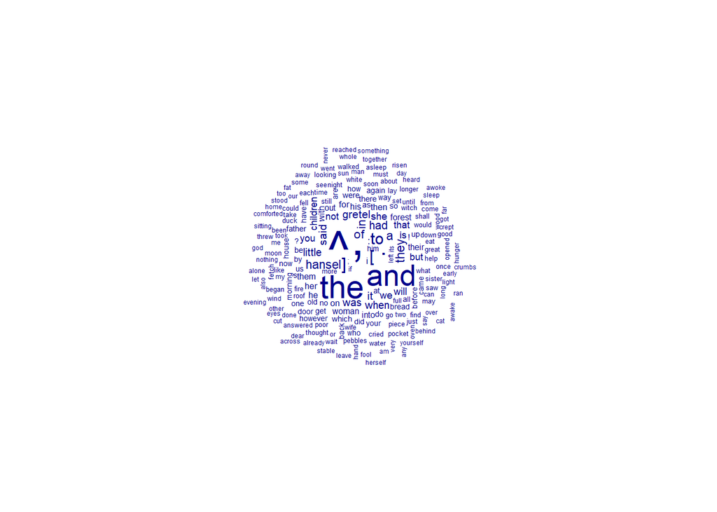

```r
quanteda::textplot_wordcloud( dfm(my.story) );
```

Not a very interesting word cloud yet. And it appears that the nature of this word cloud is “okay” but not great. See http://www.wordle.net/create. The best version I have seen. You can review HighCharts https://www.highcharts.com/demo/wordcloud and google for other solutions in R.

[figure not shown]

#### 1.2.3.2 Stop words

Many times there are “throw-away” words in a language. Used a lot but with very little meaning added to a story. These words can be thrown away, and can be used as a marker for decomposing word strings.

The folder ‘stop-info’ has some information about the process of using stop words. The folder ‘stop-templates’ have common lists I use in my research. Let’s see what quanteda has.

https://quanteda.io/reference/stopwords.html

```r
head( quanteda::stopwords(), 25);
```

```
##  [1] "i"          "me"         "my"         "myself"     "we"
##  [6] "our"        "ours"       "ourselves"  "you"        "your"
## [11] "yours"      "yourself"   "yourselves" "he"         "him"
## [16] "his"        "himself"    "she"        "her"        "hers"
## [21] "herself"    "it"         "its"        "itself"     "they"
```

When I do my “patent research”, I create patent-specific stop words. “This present invention relates to” is a common “stop-phrase” not a “stop word”.

#### 1.2.3.3 Some cleanup

When we cleanup text, we often then treat it as a “bag of words”; that is we really do not worry about the relationships of words together; it is **as-if** we through the words in a blender.

When we still care about words, we can create “n-grams”; for example a bi-gram (or 2-gram) would maintain pairs of contiguous words [not interrupted by a stop word or punctuation].

Let’s keep it simple for now.

##### 1.2.3.3.1 Remove Punctuation

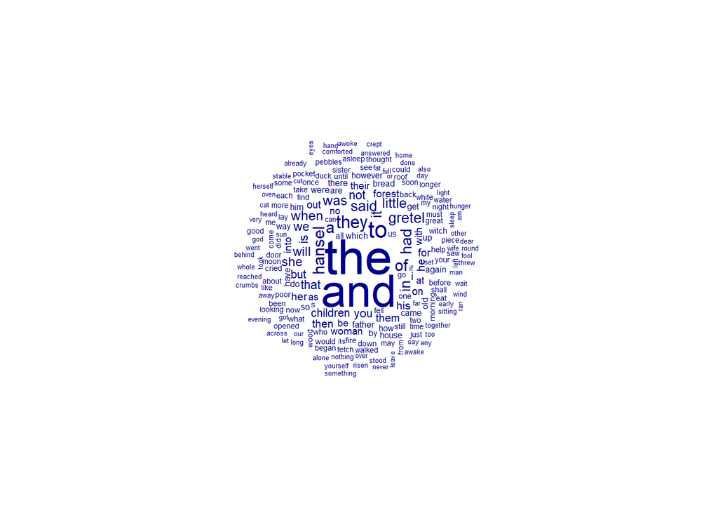

```r
my.story.q = quanteda::tokens(my.story,
                    remove_punct = TRUE,
                    remove_symbols = TRUE,
                    remove_numbers = TRUE,
                    remove_url = TRUE);

# notice the format is no longer a single char vector
quanteda::textplot_wordcloud( dfm(my.story.q) );
```

##### 1.2.3.3.2 Apply default stopwords

The `dfm` function is converting a long character string, or a vector of strings into a special class that `quanteda` has developed.

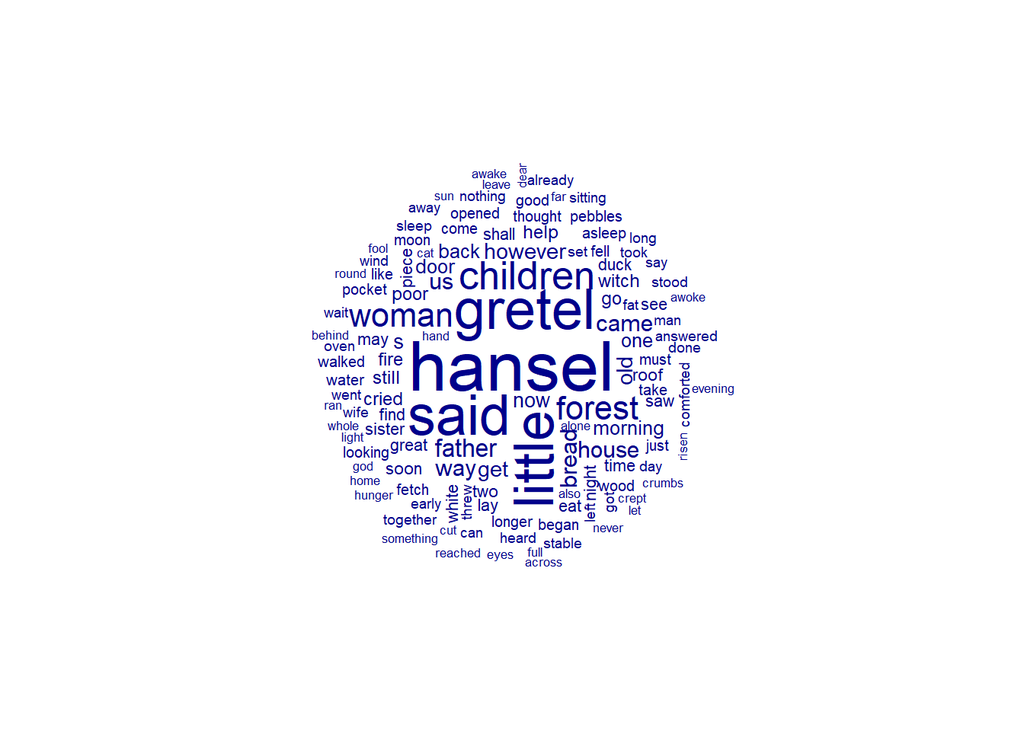

```r
my.story.dfm = quanteda::dfm( my.story.q,
                      remove = quanteda::stopwords()
);

quanteda::textplot_wordcloud(my.story.dfm);
```

##### 1.2.3.3.3 Apply stopwords `tennessee`

```r
stop.file.tennessee = paste0(path.to.nlp, "stop-templates/tennessee.txt");

stop.tennessee = strsplit( grabHTML(stop.file.tennessee), "\r\n")[[1]];
```

```
## [1] "grabHTML() ... from cache ... C:/Users/Alexander Nevsky/Dropbox/WSU-419/Fall 2020/__student_access__/unit_02_confirmatory_data_analysis/nascent/nlp/stop-templates/tennessee.txt"
```

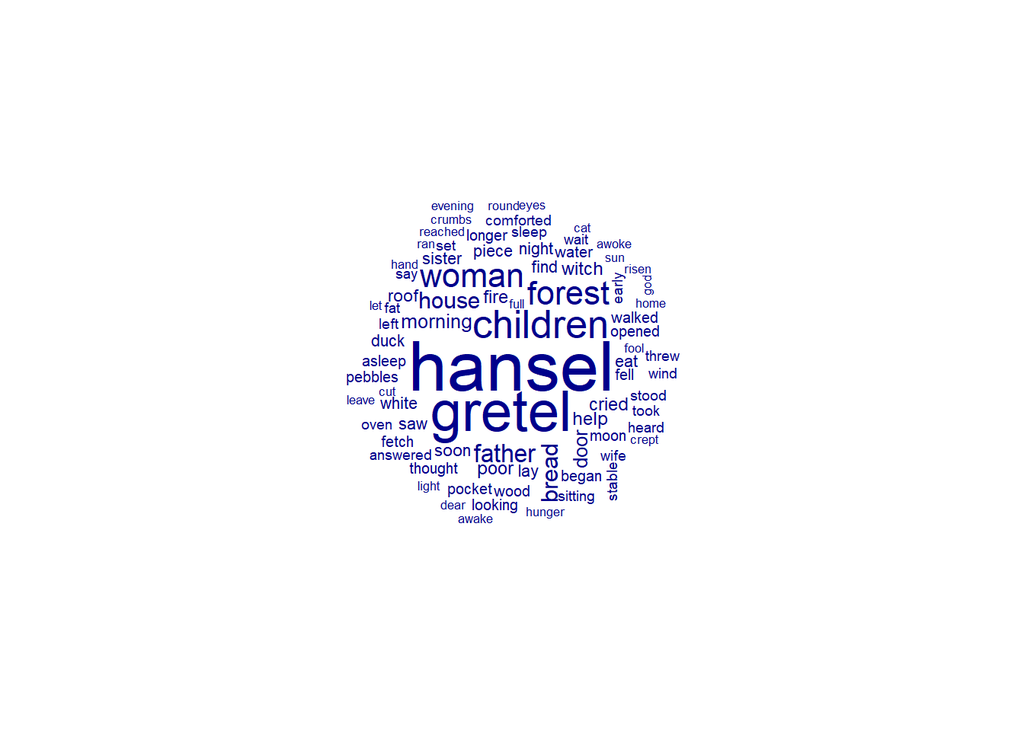

```r
# stop.tennessee;


my.story.dfm = quanteda::dfm( my.story.q,
                      remove = stop.tennessee
);

quanteda::textplot_wordcloud(my.story.dfm);
```

#### 1.2.3.4 (POS) Summary

Parts of Speech (POS) includes: nouns, verbs, pronouns, adverbs, and so on. We can implement by tying it into a python wrapper (optional developing notebook), or by using (YET another) R package.

https://cran.r-project.org/web/packages/openNLP/openNLP.pdf

```r
#install.packages ("openNLP", dependencies=TRUE);
library(openNLP);
library(NLP);
s = my.story;

## Need sentence and word token annotations.
sentence.a = Maxent_Sent_Token_Annotator();
word.a     = Maxent_Word_Token_Annotator();
sw.a       = annotate(s, list(sentence.a, word.a));

pos.a      = Maxent_POS_Tag_Annotator(probs=TRUE);
swpos.a    = annotate(s, list(pos.a), sw.a);

swpos.a.words = subset(swpos.a, type=="word");

head(swpos.a.words);
```

```
##  id  type start end features
##  133 word     1   4 POS=NNP, POS_prob=0.7723837
##  134 word     6   7 POS=IN, POS_prob=0.9568025
##  135 word     9   9 POS=DT, POS_prob=0.9936994
##  136 word    11  15 POS=JJ, POS_prob=0.98664
##  137 word    17  22 POS=NN, POS_prob=0.9870879
##  138 word    24  28 POS=VBP, POS_prob=0.9173717
```

```r
tags = sapply(swpos.a.words$features, `[[`, "POS");
sort(table(tags),decreasing = TRUE);
```

```
## tags
##   NN    ,  VBD  PRP   IN   DT   RB   CC   JJ    .   VB  NNP  NNS   TO PRP$   MD
##  415  307  299  281  276  268  240  191  177  161  157  123   98   72   69   66
##  VBN  WRB    :  VBP  VBZ  VBG   RP  WDT   CD   WP  SYM  JJR   EX   ``  PDT  RBR
##   60   44   42   40   33   30   21   21   17   16   11    9    6    4    3    3
##   UH  JJS   ''
##    3    2    1
```

https://www.sketchengine.eu/penn-treebank-tagset/ https://cs.nyu.edu/grishman/jet/guide/PennPOS.html

Some notables:

- NN is “noun, singular or mass”
- VBD is “verb be, past tense”
- PRP is “personal pronoun”
- IN is “preposition or subordinating conjunction”

**Note:** This is from the raw text. Part of the art of NLP is to figure out when to do what based on your question of interest.

#### 1.2.3.5 Other summary data

So what features can we extract? The word cloud did give us frequencies of words, so let’s review what we can capture.

##### 1.2.3.5.1 Punctuation

```r
# count .
myCounts = c();

countMe = c(".",";",":",",","?","!","^[^","^]^");
labelMe = c("P.per","P.semi","P.colon","P.comma","P.quest","P.exclam","P.left","P.right");

cn = length(countMe);
countR = c();
for(i in 1:cn)
  {
  tmp = strsplit(my.story,countMe[i],fixed=TRUE)[[1]];
  countR[i] = length(tmp);
  }


names(countR) = labelMe;
countR = as.data.frame(t(countR));

countR$P.apost = countR$P.right - countR$P.left; # apostrophes ... some poetry elemenents may have LSQ RSQ and technically be an apostrophe, see... ‘O’er hill and o’er dale
# ‘I’ll tell you what, husband,’ ... grabbing "conversation" may be a bit tricky ...

countR;
```

| P.per | P.semi | P.colon | P.comma | P.quest | P.exclam | P.left | P.right | P.apost |
| --- | --- | --- | --- | --- | --- | --- | --- | --- |
| 117 | 12 | 31 | 302 | 12 | 15 | 69 | 80 | 11 |

If you compare to the (POS) Summary, we are getting slightly different results.

##### 1.2.3.5.2 Capitalization

```r
# my.story.n = cleanupHTMLentities(my.story, find="cs", replace="rs");

my.story.n = my.story;
# remove punctuation altogether

for(i in 1:cn)
  {
  my.story.n = gsub(countMe[i],"",my.story.n,fixed=TRUE);
  }

my.story.n = removeWhiteSpace(my.story.n);

words = strsplit(my.story.n," ",fixed=TRUE)[[1]];

count.words = wc = length(words); # word count

count.lower = count.upper = count.ucfirst = 0;

details = list( "lower" = c(),
                "upper" = c(),
                "ucfirst" = c());

for(i in 1:wc)
  {
  word = words[i];

  word.lower = tolower(word);
  word.upper = toupper(word);

  if(word == word.lower)
    {
    count.lower = 1 + count.lower;
    details$lower = c(details$lower,word);
    } else if(word == word.upper)
    {
    count.upper = 1 + count.upper;
    details$upper = c(details$upper,word);
    } else {
            count.ucfirst = 1 + count.ucfirst;
            details$ucfirst = c(details$ucfirst,word);
            }

  }


countR$count.words = count.words;
countR$count.lower = count.lower;
countR$count.upper = count.upper;
# we assume if not "ALL" or "all" that it is ucfirst "All" ... # see PERL/PHP
countR$count.ucfirst = count.ucfirst;


# str(details);

head( sort(table(details$lower),  decreasing = TRUE) );
```

```
##
##  the  and   to    a they   of
##  159  156   72   43   42   41
```

```r
head( sort(table(details$upper),  decreasing = TRUE) );
```

```
##
##  I  A  B  O
## 21  1  1  1
```

```r
head( sort(table(details$ucfirst),decreasing = TRUE) );
```

```
##
## Hansel Gretel    The   When   Then    And
##     44     35     21     14     13      9
```

```r
countR;
```

| P.per | P.semi | P.colon | P.comma | P.quest | P.exclam | P.left | P.right | P.apost | count.words | count.lower | count.upper | count.ucfirst |
| --- | --- | --- | --- | --- | --- | --- | --- | --- | --- | --- | --- | --- |
| 117 | 12 | 31 | 302 | 12 | 15 | 69 | 80 | 11 | 2929 | 2684 | 24 | 221 |

Notice we could count Hansel and Gretel and there seems to be a bit of a gender bias. Hansel = 44, Gretel = 35. We can however, count gender-specific words that would allow us to compare the short stories. Many of the short stories speak of kingdoms, forests, trees, wolves, and so on. So we could grab features that may be similar across them…

My last name “SHAFFER” is of German origin; and it was said that until about the year 1500, a family’s name was a function of the house they lived in. (Johannes Gutenberg invented printing press about that time). So if you moved “houses” your name changed. You are the family living in house “SHAFFER”.

“SHAFFER” is derived as a variant of the German word “Schäfer” which means shepherd; the “SHAFFER-hound” is the relatively modern German Shepherd dog (sheep-herd: Schäferhund) https://en.wikipedia.org/wiki/German_Shepherd; maybe “hound” originates from herding not hunting (hund) https://www.etymonline.com/word/hound as is commonly believed. Or maybe it meant “the family dog:” herder of sheep, or a hunter, or a protector of the family (watchdog alarm) https://en.wiktionary.org/wiki/Hund#Etymology_2.

##### 1.2.3.5.3 Personal Pronouns

https://en.wikipedia.org/wiki/Pronoun#English_pronouns

```r
# we have words, so let's make them lower case

# let's ignore hyphens, separate as words.
my.story.m = gsub("-"," ",my.story.n,fixed=TRUE);
my.story.m = removeWhiteSpace(my.story.m);

words.m = strsplit(my.story.m," ",fixed=TRUE)[[1]];


words.lower = tolower(words.m);

# bag of words, order doesn't matter
words.table = as.data.frame( sort(table(words.lower),decreasing = TRUE));
  colnames(words.table) = c("word","count");

my.pronouns = NULL;

pr.person = "first";
pr.number = "singular";
pronouns = c("i", "me", "my", "mine", "myself");
for(p in 1:length(pronouns))
  {
  lookup = subsetDataFrame(words.table, "word", "==", pronouns[p]);
  lookup.count = 0;
  if(dim(lookup)[1] == 1) { lookup.count = lookup$count; }
  row = c(pr.person,pr.number,pronouns[p],lookup.count);
  my.pronouns = rbind(my.pronouns,row);
  }

pr.person = "first";
pr.number = "plural";
pronouns = c("we", "us", "our", "ours", "ourselves");
for(p in 1:length(pronouns))
  {
  lookup = subsetDataFrame(words.table, "word", "==", pronouns[p]);
  lookup.count = 0;
  if(dim(lookup)[1] == 1) { lookup.count = lookup$count; }
  row = c(pr.person,pr.number,pronouns[p],lookup.count);
  my.pronouns = rbind(my.pronouns,row);
  }


pr.person = "second";
pr.number = "singular";
pronouns = c("you", "you", "your", "yours", "yourself");
for(p in 1:length(pronouns))
  {
  lookup = subsetDataFrame(words.table, "word", "==", pronouns[p]);
  lookup.count = 0;
  if(dim(lookup)[1] == 1) { lookup.count = lookup$count; }
  row = c(pr.person,pr.number,pronouns[p],lookup.count);
  my.pronouns = rbind(my.pronouns,row);
  }

pr.person = "second";
pr.number = "plural";
pronouns = c("you", "you", "your", "yours", "yourselves");
for(p in 1:length(pronouns))
  {
  lookup = subsetDataFrame(words.table, "word", "==", pronouns[p]);
  lookup.count = 0;
  if(dim(lookup)[1] == 1) { lookup.count = lookup$count; }
  row = c(pr.person,pr.number,pronouns[p],lookup.count);
  my.pronouns = rbind(my.pronouns,row);
  }

pr.person = "third";
pr.number = "singular";
pronouns = c("he", "him", "his", "his", "himself");
for(p in 1:length(pronouns))
  {
  lookup = subsetDataFrame(words.table, "word", "==", pronouns[p]);
  lookup.count = 0;
  if(dim(lookup)[1] == 1) { lookup.count = lookup$count; }
  row = c(pr.person,pr.number,pronouns[p],lookup.count);
  my.pronouns = rbind(my.pronouns,row);
  }

pr.person = "third";
pr.number = "singular";
pronouns = c("she", "her", "her", "hers", "herself");
for(p in 1:length(pronouns))
  {
  lookup = subsetDataFrame(words.table, "word", "==", pronouns[p]);
  lookup.count = 0;
  if(dim(lookup)[1] == 1) { lookup.count = lookup$count; }
  row = c(pr.person,pr.number,pronouns[p],lookup.count);
  my.pronouns = rbind(my.pronouns,row);
  }
pr.person = "third";
pr.number = "singular";
pronouns = c("it", "it", "its", NA, "itself");
for(p in 1:length(pronouns))
  {
  lookup = subsetDataFrame(words.table, "word", "==", pronouns[p]);
  lookup.count = 0;
  if(dim(lookup)[1] == 1) { lookup.count = lookup$count; }
  row = c(pr.person,pr.number,pronouns[p],lookup.count);
  my.pronouns = rbind(my.pronouns,row);
  }

pr.person = "third";
pr.number = "plural";
pronouns = c("they", "them", "their", "theirs", "themself", "themselves");
for(p in 1:length(pronouns))
  {
  lookup = subsetDataFrame(words.table, "word", "==", pronouns[p]);
  lookup.count = 0;
  if(dim(lookup)[1] == 1) { lookup.count = lookup$count; }
  row = c(pr.person,pr.number,pronouns[p],lookup.count);
  my.pronouns = rbind(my.pronouns,row);
  }


  pn = dim(my.pronouns)[1];
rnames = c("subject","object","determiner","independent","reflexive");
  rn = length(rnames);
  gn = (floor(pn/rn));
rnames.all = c();
for(g in 1:gn)
  {
  rnames.all = c(rnames.all, paste0(rnames,"-",g));
  }
  rnames.all = c(rnames.all, paste0("reflexive.b-",g));

  length(rnames.all);
```

```
## [1] 41
```

```r
cnames = c("person","number","word","count");

my.pronouns = as.data.frame(my.pronouns);
  rownames(my.pronouns) = rnames.all;
  colnames(my.pronouns) = cnames;

my.pronouns$count = as.numeric(my.pronouns$count);

my.pronouns;
```

|  | person | number | word | count |
| --- | --- | --- | --- | --- |
| subject-1 | first | singular | i | 21 |
| object-1 | first | singular | me | 5 |
| determiner-1 | first | singular | my | 5 |
| independent-1 | first | singular | mine | 0 |
| reflexive-1 | first | singular | myself | 1 |
| subject-2 | first | plural | we | 28 |
| object-2 | first | plural | us | 11 |
| determiner-2 | first | plural | our | 4 |
| independent-2 | first | plural | ours | 0 |
| reflexive-2 | first | plural | ourselves | 2 |

[output cut: 31 more lines]

##### 1.2.3.5.4 Gender-specific

```r
my.gender = NULL;

g.person = "male";
g.number = "singular";
genders = c("he", "him", "his", "himself", "man", "boy", "king", "prince", "son", "father", "dad", "daddy", "fatherhood", "brother", "godfather", "gentleman", "huntsman", "fisherman", "groom", "husband");

for(g in 1:length(genders))
  {
  lookup = subsetDataFrame(words.table, "word", "==", genders[g]);
  lookup.count = 0;
  if(dim(lookup)[1] == 1) { lookup.count = lookup$count; }
  row = c(g.person,g.number,genders[g],lookup.count);
  my.gender = rbind(my.gender,row);
  }

g.person = "male";
g.number = "plural";  # plural may be capturing possessive "father's"?
genders = c("men", "boys", "kings", "princes", "sons", "fathers", "dads", "daddies", "brothers", "brethren", "brotherhood", "godfathers", "gentlemen", "huntsmen", "fishermen", "husbands");

for(g in 1:length(genders))
  {
  lookup = subsetDataFrame(words.table, "word", "==", genders[g]);
  lookup.count = 0;
  if(dim(lookup)[1] == 1) { lookup.count = lookup$count; }
  row = c(g.person,g.number,genders[g],lookup.count);
  my.gender = rbind(my.gender,row);
  }

g.person = "female";
g.number = "singular";
genders = c("she", "her", "herself", "woman", "girl", "queen", "princess", "daughter", "mother", "mom", "mommy", "motherhood", "sister", "godmother", "lady", "maid", "maiden", "bride");

for(g in 1:length(genders))
  {
  lookup = subsetDataFrame(words.table, "word", "==", genders[g]);
  lookup.count = 0;
  if(dim(lookup)[1] == 1) { lookup.count = lookup$count; }
  row = c(g.person,g.number,genders[g],lookup.count);
  my.gender = rbind(my.gender,row);
  }

g.person = "female";
g.number = "plural";
genders = c("women", "girls", "queens", "princesses", "daughters", "mothers", "moms", "mommies", "sisters", "sisterhood", "godmothers", "ladies", "maids", "maidens");

for(g in 1:length(genders))
  {
  lookup = subsetDataFrame(words.table, "word", "==", genders[g]);
  lookup.count = 0;
  if(dim(lookup)[1] == 1) { lookup.count = lookup$count; }
  row = c(g.person,g.number,genders[g],lookup.count);
  my.gender = rbind(my.gender,row);
  }






cnames = c("gender","number","word","count");

my.gender = as.data.frame(my.gender);
  rownames(my.gender) = NULL;
  colnames(my.gender) = cnames;

my.gender$count = as.numeric(my.gender$count);

my.gender;
```

| gender | number | word | count |
| --- | --- | --- | --- |
| male | singular | he | 21 |
| male | singular | him | 11 |
| male | singular | his | 21 |
| male | singular | himself | 2 |
| male | singular | man | 3 |
| male | singular | boy | 1 |
| male | singular | king | 0 |
| male | singular | prince | 0 |
| male | singular | son | 0 |
| male | singular | father | 8 |

[output cut: 58 more lines]

##### 1.2.3.5.5 Grimm-specific

We could also capture proper names like “HANSEL” and “GRETEL”, but this demonstrates this idea.

I would try and capture the language in “German” and translate using a classifier. We are capturing general themes of the original stories, but the “translators” have added their cultural/linguistic bias to what we have. “Miles and yards” are clues to a potential bias.

In an optional notebook, I will show the basic mechanics of a “translation” classifier by examining the book of Genesis in English and Chinese.

I also want to emphasize the importance of “getting intimate with your data.” You can run this analysis through `quanteda` and could possibly miss some feature-insights.

```r
grimms = c("wolf/wolves", "bear/s", "fox/es", "bird/s", "forest/s", "iron/s", "fish/ed/es/fishing/fisherman/fishermen/fishpond/s",  "tree/s", "house/s", "garden/s", "bread/s", "water/s", "hand/s", "pure", "lock/s", "finger/s", "toe/s", "leg/s", "arm/s", "head/s", "foot/feet/footed", "bar/s", "stomach/e/belly", "walk/s/ed", "run/runs/ran", "loaf/loaves", "search/searching/searches/searched", "sea/s", "prophet/s/prophecy/prophecies", "small/large", "emperor/s", "pope/s", "fly/flies/flew", "child/children", "dwarf/dwarves", "witch/es", "moon/s", "raven/s", "cake/s", "sweet/s", "apple/s", "lake/s", "axe/s", "wood/s", "hill/s", "hat/s", "goose/geese", "box/es", "wheel/s", "tower/s", "boil/boiled/boils", "lamb/s", "tail/s", "grove/s", "field/s", "voice/s", "cheese", "coat/s", "rose/s/y", "bushe/s", "feast/s", "wake/s/awaken/rise/n/arose", "enemy/enemies", "better/best", "worse/worst", "pocket/s", "coffin/s", "hungry/hunger/weary/weariness", "cage/s", "chicken/s", "light/s", "dark/darken/darkness", "board/s", "candle/s", "eye/s", "girdle/s", "sleep/asleep/sleeps/rest/rests/rested/restful", "round/s", "circle/s/ed", "square/s/ed", "eat/ate/eaten/eats/", "fire/s", "yard/s", "breast/s", "pigeon/s", "cook/cooked/cooking/cooks", "wild", "beast/s", "devour/s", "god/less", "winter/s", "yes", "no", "soldier/s", "prison/s", "prisoner/s", "grass/es", "rope/roped/ropes", "shoulder/s", "art/s", "cunning/think/thought", "friend/ly/s", "leaf/leaves", "whistle/whistling/whistled/whistles", "year/s", "month/s", "week/s", "dream/s", "gay/happy/sad/unhappy", "sword/s", "air/s", "sing/s/singing/sung", "bone/s", "silk", "well/s",  "day/s",  "evening/s", "morning/s",  "night/s",  "castle/s",  "door/s", "marble/s", "gold/golden/silver/pearls/jewels",  "good/peace", "wicked/evil", "cow/s", "goat/s", "bee/s", "milk/honey", "window/s", "marry/marries/married", "kid/s", "bed/s", "key/s", "giant/s", "today/tomorrow/yesterday", "wish/wished/wishes", "priest/s/priesthood", "sun/s", "frog/s", "fog/s", "summer/s", "spring/s", "fall/s", "autumn/s", "young/younger/youngest", "old/older/oldest/eldest", "leather", "peasant/s", "shepherd", "mayor/s", "hole/s", "barrel/s", "straw", "devil", "servant/s", "sheep", "flock", "cottage/s", "bedchamber/s", "room/s", "kitchen", "courtyard/s", "cabbage/s", "chain/s", "hot/cold/warm", "spirit/s", "red/blue/white/green/s/black/yellow/purple", "blood/bleeding/bleeds", "pig/s", "horse/s", "dog/s", "die/death/dying/died/dies/dead", "kill/killed/kills", "birth/born", "fallen", "handsome/handsomest /beautiful/lovely", "glass", "ball/s", "mouse/mice/mouses/", "cat/s", "mountain/s", "pot/s", "fat/s", "on/off",  "live/lives/life/lived/alive", "early/late", "shoe/s", "stone/s", "pebble/s", "drawer/s", "table/s", "plate/s", "bowl/s", "piece/s", "body/bodies", "salt/pepper", "left/right", "top/bottom", "cut/s", "wine/s", "home/s", "knife/knives", "fork/forks", "spoon/s/spoonful", "cloth/es/clothing", "treasure/s", "guest/s",  "war/wars/battle/battles/battlefield", "animal/s", "pillow/s", "food/feed/breakfast/s/lunch/es/dinner/s/supper/s", "beam/s", "robber/s", "monster/s", "tooth/teeth", "music/musician", "donkey/s", "bit/bite/bites/bitten", "club/s", "stick/s", "storm/s/y", "shelter/s/ed", "drink/drunk/drinks/drunken", "meadow/s", "branch/es", "ring/s",  "cry/cries/cried/weep/wept/", "snow/s/snowflake/s", "rain/s", "heart/s", "love/lover/loved/loves", "country/countryside", "land/s", "little/big", "duck/s", "or/and/but", "also/too", "thirsty/drink", "wren/s", "nest/s", "egg/s",  "one/two/three/four/five/six/seven/eight/nine/ten/eleven/twelve/thirteen", "ones/twos/threes/fours/fives/sixes/sevens/eights/nines/tens/elevens/twelves/thirteens", "church/es", "lip/s", "half/whole", "first/second/third/fourth/fifth/sixth/seventh/eighth/ninth/tenth/eleventh/twelfth/thirteenth",  "hundred/s", "thousand/s", "heaven/s", "heavy", "wind/y", "poor/rich", "mile/s" );

all.words = c();
for(g in 1:length(grimms))
  {
  sub.g = strsplit(grimms[g],"/",fixed=TRUE)[[1]];
  n.g = length(sub.g);
  sub.previous = NULL;
  for(i in 1:n.g)
    {
    s = sub.g[i];
    if(i > 1)
      {
      s.n = nchar(s);
      if(s.n < 3) # we have a token-stem
        {
        all.words = c(all.words, paste0(sub.previous,s)); # append
        } else {
                all.words = c(all.words, s); # next one
                sub.previous = s;
                }
      } else {
              all.words = c(all.words, s); # first one
              sub.previous = s;
              }
    }
  #
  }
## above would be "nice" to somehow keep them grouped based on the single entry...


my.grimm = NULL;
for(a in 1:length(all.words))
  {
  # could do wildcard ...
  lookup = subsetDataFrame(words.table, "word", "==", all.words[a]);
  lookup.count = 0;
  if(dim(lookup)[1] == 1) { lookup.count = lookup$count; }
  row = c(all.words[a],lookup.count);
  my.grimm = rbind(my.grimm,row);
  }




cnames = c("word","count");  # "group" would be nice

my.grimm = as.data.frame(my.grimm);
  rownames(my.grimm) = NULL;
  colnames(my.grimm) = cnames;

my.grimm$count = as.numeric(my.grimm$count);

my.grimm;
```

| word | count |
| --- | --- |
| wolf | 0 |
| wolves | 0 |
| bear | 1 |
| bears | 0 |
| fox | 0 |
| foxes | 0 |
| bird | 2 |
| birds | 1 |
| forest | 16 |
| forests | 0 |

[output cut: 617 more lines]

I spent about two hours “randomly” scanning word-elements of the stories to build this conceptual word-group list. This project is a bit of “supervised learning” since human intervention was required to specifically consider some words. In a future notebook, we will show a “unsupervised learning” technique.

#### 1.2.3.6 Bigrams and stop words?

I could return to the idea of bigrams (2-grams) and stop words. Instead of stop words, or in addition to stop words, I could use my “grimm-specific” list to include “go words”.

```r
## maybe create [stop] tag for comma, semicolon, and so on ... it becomes a "word" == "[stop]" as in a punctuation break ...

stop.file.snowball = paste0(path.to.nlp, "stop-templates/snowball.txt");

stop.snowball = strsplit( grabHTML(stop.file.snowball), "\r\n")[[1]];
```

```
## [1] "grabHTML() ... from cache ... C:/Users/Alexander Nevsky/Dropbox/WSU-419/Fall 2020/__student_access__/unit_02_confirmatory_data_analysis/nascent/nlp/stop-templates/snowball.txt"
```

```r
# stop.tennessee
# grimms
# words.lower = tolower(words.m);
uni.grams = c();
bi.grams = c();
#my.stop = stop.tennessee;
#my.stop = NULL;
my.stop = stop.snowball;
verbose = FALSE;

bigram = NULL;
for(i in 1:length(words.lower))
  {
  # for simplicity, we will just do stopwords
  word = words.lower[i];
  if(verbose) { print(paste0("word: ",word)); }
  if(is.element(word, my.stop))
    {
    if(length(bigram) == 2)
      {
      # could be just one ...
      # since we store uni.grams, let's dump it
      bi.grams = c(bi.grams, paste0(bigram,collapse=" "));
      }
    bigram = NULL;
    } else {
            uni.grams = c(uni.grams,word);
            bigram = c(bigram,word);
            if(verbose) { print(paste0("bigram: ", paste0(bigram,collapse=":"))); }
            if(length(bigram) == 2)
              {
              bi.grams = c(bi.grams, paste0(bigram,collapse=" "));
              # keep the 2nd for next possible contiguous bigram
              bigram = bigram[2];
              }
            }

  }
  if(length(bigram) > 0)
      {
      # could be just one ...
      bi.grams = c(bi.grams, paste0(bigram,collapse=" "));
      bigram = NULL;
      }

# watch this scroll in buffer with print turned on is interesting... can you read the story?


head( sort(table(uni.grams),decreasing = TRUE), 25);
```

```
## uni.grams
##   hansel   gretel     said   little      she     will children      his
##       44       35       35       34       28       28       23       21
##        i    woman   forest    bread     came    house       us      way
##       21       18       16       11       11       11       11       11
##      get  however      old      now     back     door   father  morning
##       10       10       10        9        8        8        8        8
##      one
##        8
```

```r
head( sort(table(bi.grams),decreasing = TRUE), 25);
```

```
## bi.grams
##    said hansel         i will      old woman     his little   little house
##              7              6              6              5              5
##  little sister        help us     his pocket    little duck    father said
##              5              4              4              4              3
##  fathers house hansel however  little stable  poor children      said just
##              3              3              3              3              3
##      she cried      soon find    stood still   two children      will soon
##              3              3              3              3              3
##      will take  woman however  comforted his   cried hansel     dark night
##              3              3              2              2              2
```

- The above could include a “[stop]” key for punctuation.
- This logic could be extended to include: 3-grams, 4-grams, etc.
- You could build n-grams with overinflation. If a 5-gram exists, build all of its possible 4-grams, 3-grams, 2-grams, and 1-grams. I call the creation of features without inflation the “disjoint” method.
- You could also use POS to alter the order of a modifiers. “urostomy plastic bag” and “plastic urostomy bag” have the exact same meaning.

#### 1.2.3.7 Sparse reduction

We could easily create a “cut-off” rule based on frequencies (especially for 1-grams) to present fewer elements into the next round of analysis.

#### 1.2.3.8 (STEMMING) Variant reduction

Above, you will notice that I addressed the singular/plural of a word one-at-a-time. It is important to understand how this could work manually. A “stemmer” or “lemmatizer” is the process of doing this. I like to store a dictionary of the subcounts of the reduced values and each variant.

https://programmerbackpack.com/lemmatization-and-stemming-in-nlp-the-complete-practical-guide/

I call this process “stemming”.

##### 1.2.3.8.1 Snippet of 3-gram

Below is an example of a snippet of a JSON object that has the count for 3-grams from patent data. At the time, python did not have a sorting mechanism (ARGH!). This text was about “sms messaging” - `scikit-learn ntlk` did the transformations.

```
{ “servic+lb+queri”: 4, “sm+multimedia+messag”: 5, “proxi+messag+includ”: 2, “gateway+mobil+locat”: 2, “proxi+messag+extract”: 1, “sm+messag+accord”: 30, “locat+base+servic”: 38, “base+servic+lb”: 4, “allow+locat+base”: 21, “proxi+messag+mean”: 2, “messag+compris+receiv”: 1, … }
```

##### 1.2.3.8.2 Snippet of 2-gram variant file

```
"program+repres": {
  "programs+represented": 1
 },
 "typic+includ": {
  "typically+include": 1,
  "typically+includes": 3
 },
 "larger+commun": {
  "larger+community": 1
 },
 "teloc+numer": {
  "telocator+numeric": 1
 },
 "airlin+schedul": {
  "airline+schedule": 1
 },
```

#### 1.2.3.9 Conclusion

It is very important to understand your data, so before comparing multiple stories (next notebook), let’s have you do some basic descriptive analysis of the this single story (or you can pick a different single story if you want). Pie charts of gendered words? Personal Pronounces? Capitalization? Punctuation?

```r
# do some basic analysis (likely descriptive) on this single story.  (pie chart maybe)?
```

##### 1.2.3.9.1 Quanteda

I am not completely sold on Quanteda. It appears to be linking to other packages, like “wordStem” which I could do. I tried to install “spaCy” in Python on Win10 using pip for POS analysis (as recommended by quanteda). It failed miserably, as this package is not `scikit-learn` … I will make an optional short “developing” notebook (and video) on the python workspace.

##### 1.2.3.9.2 corpus

- https://cran.r-project.org/web/packages/corpus/vignettes/corpus.html
- http://corpustext.com/
- https://github.com/leslie-huang/r-corpus

This was developed by a student while working on a Ph.D. in NLP at NYU and has been handed over to a new maintainer.

##### 1.2.3.9.3 tm

- http://tm.r-forge.r-project.org/
- https://www.jstatsoft.org/article/view/v025i05
- https://cran.r-project.org/web/packages/tm/vignettes/tm.pdf

This is an older package. It uses parallel and Rcpp to speed up the slowness of R in processing text.

##### 1.2.3.9.4 Final answer

Each of the above have “walk-throughs” for black-box operations. Since I have developed a proprietary methodology (which I will discuss in an optional mastery notebook), I struggle with limitations of each. You want to be able to scan the text in multiple ways to extract certain features. It is likely I will just build my own functions and tie-into their “wordclouds” or something.

The 5-stages for classification from last notebook:

- How we select the data
- How we divide the data
- What data features we can extract
- How to compare the given features
- What statistics will determine the prediction

I would not suggest R or Python for data pre-processing. I allowed one worker to convince me to use Python (because he was very comfortable programming that way). We bought a new server with faster hard-drives to read data faster (10 million documents). Ultimately, if you want to scale past hobby-hour, I would suggest: C/C++, Perl, PHP, Java for building out the necessary objects. However, that is a challenge. If you can do a raw prep of the data in one of these languages, then you could use `scikit-learn ntlk` to do the other special stuff (like maybe gender classification: https://stackoverflow.com/questions/16323078/gender-identification-in-natural-language-processing#16328613). End of the day, once you have features and want to do clustering, classification, or other multivariate statistics, I would recommend returning to R. Ultimately, you choose the best tools for the job, so may develop an ensemble of tools based on the task required at the time.